# Tipología y Ciclo de Vida de los Datos - Práctica 2

Alberto Ayora Pais

Enero 2020

# Limpieza y Análisis de los datos

## 1. Introducción

### 1.1. Presentación

En esta práctica se elabora un caso práctico orientado a aprender a identificar los datos relevantes para un proyecto analítico y usar las herramientas de integración, limpieza, validación y análisis de las mismas. Para hacer esta práctica tendréis que trabajar en grupos de 2 personas. Tendréis que entregar un solo archivo con el enlace Github (https://github.com) donde se encuentren las soluciones incluyendo los nombres de los componentes del equipo. Podéis utilizar la Wiki de Github para describir vuestro equipo y los diferentes archivos que corresponden a vuestra entrega.

### 1.2. Competencias

En esta práctica se desarrollan las siguientes competencias del Máster de Data Science:

- Capacidad de analizar un problema en el nivel de abstracción adecuado a cada situación y aplicar las habilidades y conocimientos adquiridos para abordarlo y resolverlo.
- Capacidad para aplicar las técnicas específicas de tratamiento de datos (integración, transformación, limpieza y validación) para su posterior análisis.

### 1.3. Objetivos

Los objetivos concretos de esta práctica son:

- Aprender a aplicar los conocimientos adquiridos y su capacidad de resolución de problemas en entornos nuevos o poco conocidos dentro de contextos más amplios o multidisciplinares.
- Saber identificar los datos relevantes y los tratamientos necesarios (integración, limpieza y validación) para llevar a cabo un proyecto analítico.
- Aprender a analizar los datos adecuadamente para abordar la información contenida en los datos.
- Identificar la mejor representación de los resultados para aportar conclusiones sobre el problema planteado en el proceso analítico.
- Actuar con los principios éticos y legales relacionados con la manipulación de datos en función del ámbito de aplicación.
- Desarrollar las habilidades de aprendizaje que les permitan continuar estudiando de un modo que tendrá que ser en gran medida autodirigido o autónomo.
- Desarrollar la capacidad de búsqueda, gestión y uso de información y recursos en el ámbito de la ciencia de datos.

## 2. Resolución

### 2.1. Descripción del dataset

El dataset proporcionado en la URL https://www.kaggle.com/rusiano/madrid-airbnb-data contiene información procedente de la web www.airbnb.com para la ciudad de Madrid. Esta información será muy útil para realizar un estudio del estado del alquiler de habitaciones de este tipo en la ciudad de Madrid y obtener información sobre qué factores inciden más sobre el alquiler del precio, zonas donde saldría más rentable alquilar y en qué época del año, etcc.

### 2.2. Selección de datos

Cargamos los diferentes datasets y hacemos una primera selección de variables en el dataset **listings_detailed.csv**, con el objetivo de reducir el número de variables a trabajar en el estudio. Las variables descartadas se trata de variables que no se quieren analizar en este primer estudio y se considera que su eliminación no afectaría a la integridad de la muestra original.

```r
# datasets secundarios
neighbourhoods.dataset <- read.csv('neighbourhoods.csv', header = TRUE, sep = ',', strip.white = TRUE)

head(neighbourhoods.dataset)
```

```
##   neighbourhood_group neighbourhood
## 1          Arganzuela       Acacias
## 2          Arganzuela        Atocha
## 3          Arganzuela       Chopera
## 4          Arganzuela      Delicias
## 5          Arganzuela      Imperial
## 6          Arganzuela       Legazpi
```

```r
calendar.dataset <- read.csv('calendar.csv', header = TRUE, sep = ',', strip.white = TRUE)

head(calendar.dataset)
```

```
##   listing_id       date available  price adjusted_price minimum_nights
## 1     336834 2019-09-19         f $63.00         $63.00              5
## 2       6369 2019-09-19         f $70.00         $70.00              1
## 3       6369 2019-09-20         f $75.00         $75.00              1
## 4       6369 2019-09-21         f $75.00         $75.00              1
## 5       6369 2019-09-22         t $70.00         $70.00              1
## 6       6369 2019-09-23         t $70.00         $70.00              1
##   maximum_nights
## 1            250
## 2            365
## 3            365
## 4            365
## 5            365
## 6            365
```

```r
# dataset principal
dataset.aux <- read.csv("listings_detailed.csv", header = TRUE, sep = ',', strip.white = TRUE)

listings.detailed.dataset <- select(dataset.aux, "id", "host_id", "host_response_time", "host_response_rate", "host_acceptance_rate", "host_identity_verified", "street", "neighbourhood_cleansed", "neighbourhood_group_cleansed", "city", "state", "zipcode", "country_code", "country", "latitude", "longitude", "is_location_exact", "room_type", "accommodates", "bathrooms", "bedrooms", "beds", "bed_type", "square_feet", "price", "security_deposit", "cleaning_fee", "number_of_reviews", "reviews_per_month", "number_of_reviews_ltm", "first_review", "last_review", "review_scores_rating", "review_scores_accuracy", "review_scores_cleanliness", "review_scores_checkin", "review_scores_communication", "review_scores_location", "review_scores_value", "instant_bookable", "cancellation_policy")


# las variables relacionadas con los precios son de tipo Factor en los datasets, es necesario convertirlas a tipo numérico para poder trabajar con ellas adecuadamente

listings.detailed.dataset$price <- as.numeric(gsub('$','', as.character(listings.detailed.dataset$price), fixed = TRUE))
listings.detailed.dataset$security_deposit <- as.numeric(gsub('$','', as.character(listings.detailed.dataset$security_deposit), fixed = TRUE))
listings.detailed.dataset$cleaning_fee <-  as.numeric(gsub('$','', as.character(listings.detailed.dataset$cleaning_fee), fixed = TRUE))

calendar.dataset$price <-  as.numeric(gsub('$','', as.character(calendar.dataset$price), fixed = TRUE))
calendar.dataset$adjusted_price <- as.numeric(gsub('$','', as.character(calendar.dataset$adjusted_price), fixed = TRUE))
```

El dataset principal lo completaremos con información extraida del dataset **calendar.csv**. Calcularemos el precio mínimo y máximo para cada una de las habitaciones de las que disponemos de información:

```r
min.max.prices <- calendar.dataset %>% group_by(listing_id) %>% summarise(min_price = min(price), max_price = max(price))

listings.detailed.dataset <- merge(listings.detailed.dataset, min.max.prices, by.x = 'id', by.y = 'listing_id', all.x = TRUE)

head(listings.detailed.dataset[, c('id', 'price', 'min_price', 'max_price')])
```

```
##      id price min_price max_price
## 1  6369    70        70       120
## 2 21853    17        17        18
## 3 24805    80        80       150
## 4 24836   115       115       115
## 5 26825    25        25        27
## 6 30320    65        65        65
```

El conjunto de datos final con el que se va a realizar el estudio contiene 20837 registros y 43 variables.

Descripción de los tipo de datos y valores contenidos en cada variable del dataset:

```r
str(listings.detailed.dataset)
```

```
## 'data.frame':    20837 obs. of  43 variables:
##  $ id                          : int  6369 21853 24805 24836 26825 30320 30959 40916 59923 62423 ...
##  $ host_id                     : int  13660 83531 101471 101653 114340 130907 132883 130907 288380 303845 ...
##  $ host_response_time          : Factor w/ 6 levels "","a few days or more",..: 5 3 4 5 6 6 3 6 5 6 ...
##  $ host_response_rate          : Factor w/ 72 levels "","0%","10%",..: 4 72 4 4 4 4 72 4 4 4 ...
##  $ host_acceptance_rate        : Factor w/ 2 levels "","N/A": 2 2 2 2 2 2 2 2 2 2 ...
##  $ host_identity_verified      : Factor w/ 3 levels "","f","t": 2 3 3 2 3 2 2 2 2 3 ...
##  $ street                      : Factor w/ 72 levels "\nDelicias, Madrid, Spain",..: 39 48 48 39 39 48 39 33 48 48 ...
##  $ neighbourhood_cleansed      : Factor w/ 127 levels "Abrantes","Acacias",..: 61 27 117 65 67 114 51 117 83 65 ...
##  $ neighbourhood_group_cleansed: Factor w/ 21 levels "Arganzuela","Barajas",..: 5 10 4 4 1 4 4 4 4 4 ...
##  $ city                        : Factor w/ 42 levels "","\nDelicias",..: 23 23 23 23 23 23 23 23 23 23 ...
##  $ state                       : Factor w/ 27 levels "","*Madrid","28",..: 12 18 18 12 12 18 12 10 18 18 ...
##  $ zipcode                     : num  28016 28047 28004 28004 28045 ...
##  $ country_code                : Factor w/ 1 level "ES": 1 1 1 1 1 1 1 1 1 1 ...
##  $ country                     : Factor w/ 1 level "Spain": 1 1 1 1 1 1 1 1 1 1 ...
```

[output cut: 29 more lines]

### 2.3. Limpieza de datos

Una vez cargamos los datasets con los que vamos a trabajar, llevamos a cabo una serie de operaciones para realizar la limpieza de los datos.

Una de las primeras operaciones será la de comprobar que las variables **neighbourhood_cleansed** y **neighbourhood_group_cleansed** contienen los valores correctos validándolos contra el maestro de barrios que contiene el fichero **neighbourhood.csv**

```r
match.neighbourhoods <- match(c(listings.detailed.dataset$neighbourhood_group_cleansed, listings.detailed.dataset$neighbourhood_cleansed),
                              c(neighbourhoods.dataset$neighbourhood_group, neighbourhoods.dataset$neighbourhood), nomatch = -1)

index.no.match <- which(match.neighbourhoods == -1)

length(index.no.match)
```

```
## [1] 0
```

Una vez abordado este punto, pasamos a revisar las variables que contienen ceros, elementos vacíos y/o valores extremos:

```r
# identificación de elementos vacíos
colSums(is.na(listings.detailed.dataset))
```

```
##                           id                      host_id
##                            0                            0
##           host_response_time           host_response_rate
##                            0                            0
##         host_acceptance_rate       host_identity_verified
##                            0                            0
##                       street       neighbourhood_cleansed
##                            0                            0
## neighbourhood_group_cleansed                         city
##                            0                            0
##                        state                      zipcode
##                            0                          467
##                 country_code                      country
##                            0                            0
##                     latitude                    longitude
##                            0                            0
##            is_location_exact                    room_type
##                            0                            0
##                 accommodates                    bathrooms
##                            0                           10
##                     bedrooms                         beds
##                            9                           51
##                     bed_type                  square_feet
##                            0                        20520
##                        price             security_deposit
##                          416                         7222
##                 cleaning_fee            number_of_reviews
##                         5257                            0
##            reviews_per_month        number_of_reviews_ltm
##                         4654                            0
##                 first_review                  last_review
##                            0                            0
##         review_scores_rating       review_scores_accuracy
##                         4963                         4964
##    review_scores_cleanliness        review_scores_checkin
##                         4962                         4965
##  review_scores_communication       review_scores_location
##                         4961                         4968
##          review_scores_value             instant_bookable
##                         4969                            0
##          cancellation_policy                    min_price
##                            0                          910
##                    max_price
##                          910
```

Una vez identificados debemos decidir cómo manejar estos registros que contienen valores desconocidos en algunas de las variables. Una opción podría ser eliminar esos registros que incluyen este tipo de valores, pero ello supondría desaprovechar información.

Como alternativa, se empleará un método de imputación de valores basado en la similitud o diferencia entre los registros: la imputación basada en k vecinos más próximos (en inglés, kNN-imputation). La elección de esta alternativa se realiza bajo la hipótesis de que nuestros registros guardan cierta relación. No obstante, es mejor trabajar con datos “aproximados” que con los propios elementos vacíos.

Para usar este método vamos a partir de ciertas suposiciones previas. Por ejemplo, para las variables **price** y **cleaning_fee** entendemos que un alojamiento con características similares en un mismo vecindario deberían tener unos valores similares.

```r
# al calcular el precio mínimo y máximo de algunos de los alojamientos, ya disponemos del valor para la variable price
listings.detailed.dataset$price <- ifelse(is.na(listings.detailed.dataset$price), listings.detailed.dataset$min_price, listings.detailed.dataset$price)

knn.vars <- select(listings.detailed.dataset, c('neighbourhood_cleansed', 'neighbourhood_group_cleansed', 'room_type', 'accommodates', 'bathrooms',
                      'bedrooms', 'beds', 'bed_type', 'price', 'cleaning_fee'))

listings.detailed.dataset$price <- kNN(knn.vars)$price
listings.detailed.dataset$cleaning_fee <- kNN(knn.vars)$cleaning_fee
```

En cuanto a las variables **min_price** y **max_price**, como ya tenemos cubierta la variable **price** le asignaremos el valor de esta variable por defecto:

```r
listings.detailed.dataset$min_price <- ifelse(is.na(listings.detailed.dataset$min_price), listings.detailed.dataset$price, listings.detailed.dataset$min_price)

listings.detailed.dataset$max_price <- ifelse(is.na(listings.detailed.dataset$max_price), listings.detailed.dataset$price, listings.detailed.dataset$max_price)
```

```r
colSums(is.na(listings.detailed.dataset))
```

```
##                           id                      host_id
##                            0                            0
##           host_response_time           host_response_rate
##                            0                            0
##         host_acceptance_rate       host_identity_verified
##                            0                            0
##                       street       neighbourhood_cleansed
##                            0                            0
## neighbourhood_group_cleansed                         city
##                            0                            0
##                        state                      zipcode
##                            0                          467
##                 country_code                      country
##                            0                            0
##                     latitude                    longitude
##                            0                            0
##            is_location_exact                    room_type
##                            0                            0
##                 accommodates                    bathrooms
##                            0                           10
##                     bedrooms                         beds
##                            9                           51
##                     bed_type                  square_feet
##                            0                        20520
##                        price             security_deposit
##                            0                         7222
##                 cleaning_fee            number_of_reviews
##                            0                            0
##            reviews_per_month        number_of_reviews_ltm
##                         4654                            0
##                 first_review                  last_review
##                            0                            0
##         review_scores_rating       review_scores_accuracy
##                         4963                         4964
##    review_scores_cleanliness        review_scores_checkin
##                         4962                         4965
##  review_scores_communication       review_scores_location
##                         4961                         4968
##          review_scores_value             instant_bookable
##                         4969                            0
##          cancellation_policy                    min_price
##                            0                            0
##                    max_price
##                            0
```

En cuanto a las variables **security_deposit**, **square_feet** como a todas las relativas a comentarios sobre las habitaciones, se mantendrán sus registros. Únicamente cando se haga un análisis donde se involucren se descartaran del proceso para que no se tengan en cuenta, ya que no sería posible inferir un valor concreto.

Revisamos las variables numéricas en busca de posibles valores extremos:

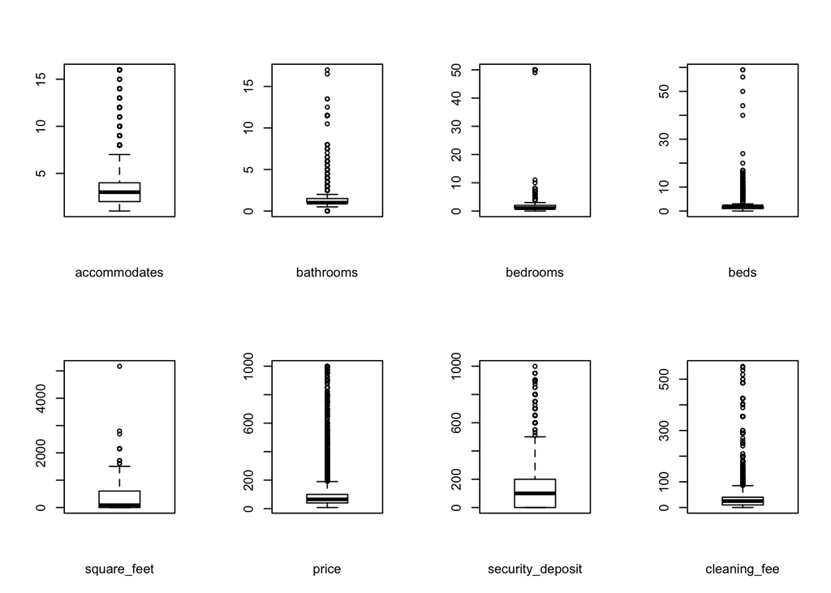

```r
par(mfrow=c(2, 4))

  boxplot(listings.detailed.dataset$accommodates, xlab = 'accommodates')

  boxplot(listings.detailed.dataset$bathrooms, xlab = 'bathrooms')

  boxplot(listings.detailed.dataset$bedrooms, xlab = 'bedrooms')

  boxplot(listings.detailed.dataset$beds, xlab = 'beds')

  boxplot(listings.detailed.dataset$square_feet, xlab = 'square_feet')

  boxplot(listings.detailed.dataset$price, xlab = 'price')

  boxplot(listings.detailed.dataset$security_deposit, xlab = 'security_deposit')

  boxplot(listings.detailed.dataset$cleaning_fee, xlab = 'cleaning_fee')
```

### 2.4. Análisis de datos

Se seleccionan los grupos dentro del conjunto de datos que pueden resultar interesantes para analizar y/o comparar:

```r
# agrupación por tipo de habitación
room.data.entire_home <- listings.detailed.dataset[listings.detailed.dataset$room_type == 'Entire home/apt', ]
room.data.hotel_room <- listings.detailed.dataset[listings.detailed.dataset$room_type == 'Hotel room', ]
room.data.private_room <- listings.detailed.dataset[listings.detailed.dataset$room_type == 'Private room', ]
room.data.shared_room <- listings.detailed.dataset[listings.detailed.dataset$room_type == 'Shared room', ]

# agrupación por tipo de cama
bed.data.airbed <- listings.detailed.dataset[listings.detailed.dataset$bed_type == 'Airbed', ]
bed.data.couch<- listings.detailed.dataset[listings.detailed.dataset$bed_type == 'Couch', ]
bed.data.futon <- listings.detailed.dataset[listings.detailed.dataset$bed_type == 'Futon', ]
bed.data.sofa <- listings.detailed.dataset[listings.detailed.dataset$bed_type == 'Pull-out Sofa', ]
bed.data.real_bed <- listings.detailed.dataset[listings.detailed.dataset$bed_type == 'Real Bed', ]
```

Comprobación de la normalidad y homogeneidad de la varianza. Se empleará la prueba de normalidad de *Anderson-Darling* para la comprobación de que los valores que toman nuestras variables cuantitativas provienen de una población distribuidad normalmente:

```r
alpha = 0.05
col.names = colnames(listings.detailed.dataset)

for (i in 1:ncol(listings.detailed.dataset)) {

    if (i == 1) cat("Variables que no siguen una distribución normal:\n")
    if (is.integer(listings.detailed.dataset[,i]) | is.numeric(listings.detailed.dataset[,i])) {
        p_val = ad.test(listings.detailed.dataset[,i])$p.value

        if (p_val < alpha) {
            cat(col.names[i])

          if (i < ncol(listings.detailed.dataset) - 1) cat(", ")

          if (i %% 3 == 0) cat("\n")
        }
    }
  }
```

```
## Variables que no siguen una distribución normal:
## id, host_id, zipcode,
## latitude,
## longitude, accommodates, bathrooms, bedrooms,
## beds, square_feet,
## price, security_deposit, cleaning_fee,
## number_of_reviews, reviews_per_month, number_of_reviews_ltm,
## review_scores_rating,
## review_scores_accuracy, review_scores_cleanliness, review_scores_checkin,
## review_scores_communication, review_scores_location, review_scores_value,
## min_price
## max_price
```

Para el estudio de la homogeneidad de varianzas se aplicará un test de *Fligner-Killeen*. En este caso en concreto, se estudiará la homogeneidad referente a los grupos conformados por las diferentes tipos de habitaciones. En el siguiente test, la hipótesis nula consiste en que ambas varianzas son iguales.

```r
fligner.test(price ~ room_type, data = listings.detailed.dataset)
```

```
##
##  Fligner-Killeen test of homogeneity of variances
##
## data:  price by room_type
## Fligner-Killeen:med chi-squared = 1006.4, df = 3, p-value <
## 2.2e-16
```

Por otro lado, queremos llevar a cabo un análisis de correlación entre las distintas variables para determinar cuales de ellas tienen mayor influencia sobre el precio de la habitación, usando para ello el coeficiente de correlación de *Spearman*:

```r
corr_matrix <- matrix(nc = 2, nr = 0)

colnames(corr_matrix) <- c("estimate", "p-value")

for (colname in colnames(listings.detailed.dataset)) {

  if(colname == 'price') next

  if (is.integer(listings.detailed.dataset[ , colname]) | is.numeric(listings.detailed.dataset[,colname]) ) {

    spearman_test = cor.test(listings.detailed.dataset[ , colname],
                             listings.detailed.dataset[ , 'price'],
                             method = "spearman")

    corr_coef = spearman_test$estimate
    p_val = spearman_test$p.value

    pair = matrix(ncol = 2, nrow = 1)
    pair[1][1] = corr_coef
    pair[2][1] = p_val
    corr_matrix <- rbind(corr_matrix, pair)
    rownames(corr_matrix)[nrow(corr_matrix)] <- colname
  }
}

print(corr_matrix)
```

```
##                                 estimate       p-value
## id                           0.053320962  1.340448e-14
## host_id                     -0.020898689  2.553910e-03
## zipcode                     -0.183555980 7.878569e-154
## latitude                     0.132718485  1.648159e-82
## longitude                    0.004021237  5.616219e-01
## accommodates                 0.591596245  0.000000e+00
## bathrooms                    0.173535345 1.695781e-140
## bedrooms                     0.411464137  0.000000e+00
## beds                         0.469937053  0.000000e+00
## square_feet                  0.261658475  2.325871e-06
## security_deposit             0.332072189  0.000000e+00
## cleaning_fee                 0.452837911  0.000000e+00
## number_of_reviews           -0.081042137  1.042655e-31
## reviews_per_month           -0.003009156  7.018878e-01
## number_of_reviews_ltm       -0.051589559  9.229767e-14
## review_scores_rating         0.048236781  1.197991e-09
## review_scores_accuracy       0.039983824  4.677160e-07
## review_scores_cleanliness    0.090490302  3.174195e-30
## review_scores_checkin       -0.004801478  5.452681e-01
## review_scores_communication  0.008477056  2.855006e-01
## review_scores_location       0.192743254 1.198300e-132
## review_scores_value         -0.003320575  6.757605e-01
## min_price                    0.947658037  0.000000e+00
## max_price                    0.854469329  0.000000e+00
```

### 2.7. Exportación de código R y de los datos producidos

El código R está incluido en el fichero con extensión **.rmd**.

Los datos de salida se exportarán mediante el siguiente código:

```r
write.csv(listings.detailed.dataset, file="airbnb_data_clean.csv")
```